# Uma extensão espaço tempo simétrica da mecânica quântica

## Futuras aplicações no problema do tempo de travessia

### 1. Introdução

Heisenberg introduziu em 1924 as seguintes relações de incerteza, referentes a [*Heisenberg Picture of quantum mechanics*](https://en.wikipedia.org/wiki/Heisenberg_picture):

$$ \begin{equation} \Delta x \Delta p \geqslant \frac{\hbar}{2} \label{eq1} \tag{1.1}\end{equation} $$

$$ \begin{equation} \Delta E \Delta t \geqslant \frac{\hbar}{2} \label{eq2} \tag{1.2}\end{equation} $$

Dos nossos conhecimentos prévios de mecânica quântica, sabemos que da equação $(1.1)$ existem operadores $x$ e $p$ tais que

$$ \begin{equation} X \left | x \right \rangle = x \left | x \right \rangle \label{eq3} \tag{1.3}\end{equation} $$

$$ \begin{equation} P \left | p \right \rangle = p \left | p \right \rangle \label{eq4} \tag{1.4}\end{equation} $$

também que tanto $\Delta x$ como $\Delta p$ podem ser interpretados como o desvio padrão dos valores esperados de seus respectivos operadores:

$$\begin{equation} \Delta x = \sqrt{\left \langle x^2 \right \rangle - \left \langle x \right \rangle^2}\label{eq5} \tag{1.5}\end{equation} $$

$$\begin{equation} \Delta p = \sqrt{\left \langle p^2 \right \rangle - \left \langle p \right \rangle^2}\label{eq6} \tag{1.6}\end{equation} $$

Mas, reside na equação $(1.3)$ um [problema a anos apontado pelo próprio pauli.](https://arxiv.org/abs/1705.09212) Sabemos dos postulados de Heisenberg na mecânica quântica que a relação de comutação entre $x$ e $p$ é:

$$\begin{equation}[X,P]= i \hbar\label{eq7} \tag{1.7}\end{equation} $$

Daí, surge a pergunta então: se interpretarmos $\Delta E$ como o desvio padrão do valor esperado do operador Hamiltoniano, teremos

$$ \begin{equation} H \left | E \right \rangle = E \left | E \right \rangle \label{eq8} \tag{1.8}\end{equation} $$

$$\begin{equation} \Delta E = \sqrt{\left \langle H^2 \right \rangle - \left \langle H \right \rangle^2}\label{eq9} \tag{1.9}\end{equation} $$

Então, será possível então expressar T em forma de uma [variável dinâmica](https://en.wikipedia.org/wiki/Heisenberg_picture#Commutator_relations), ou seja, introduzir um operador T de modo que $\Delta t$ passaria a ser interpretado como o desvio padrão do valor esperado de T?

Como já referênciamos, Pauli demonstrou que a implementação de um operador temporal na mecânica quântica faria com que a Heisenberg Picture levasse a absurdos físicos (e.g ausência de valores limitantes inferiores a um Hamiltoniano) como demonstraremos a seguir:

### 2. Breve demonstração do Argumento de Pauli

No regime proposto na sessão anterior, descrevemos as seguintes condições:

$$ H \left | E \right \rangle = E \left | E \right \rangle $$

$$ T \left | t \right \rangle = t \left | t \right \rangle $$

$$ [H, T] = i \hbar $$

Vamos então agora mostrar que o estado $ \exp[i E^\prime T/\hbar] \left | E \right \rangle $ é um autoestado do operador Hamiltoniano H, com autovalor de energia $ E - E^\prime $. Comecemos expandindo o operador exponencial em formato de série:

$$ e^{iE^\prime T/\hbar} = \sum_{n=0}^{\infty} \frac{1}{n!} \left( \frac{iE^\prime T}{\hbar} \right)^n \tag{2.1} $$

Aplicando então o operador hamiltoniano pela esquerda vamos obter que,

$$ H e^{iE^\prime T/\hbar} = \sum_{n=0}^{\infty} \frac{1}{n!} H \left( \frac{iE^\prime T}{\hbar} \right)^n \tag{2.2} $$

Agora, precisamos passar o operador hamiltoniano para a direita do operador tempo. Para isso, note que

$$HT = TH + [H,T] = TH + i\hbar \tag{2.3}$$

Onde usamos então o fato de que o teorema de Pauli supoem que $[H,T] = i\hbar$. Assim aplicando então o operador $T$ pela direita em $(2.3)$ vamos obter que

$$HT^2 = THT + i\hbar T \tag{2.4}$$

E utilizando recursivamente a equação $(2.3)$ agora no primeiro termo de $(2.4)$ é fácil ver que

$$HT^2 = T^2H + 2i\hbar T \tag{2.5}$$

De maneira similar, podemos seguir então indutivamente tal

$$HT^3 = T^3H + 2i\hbar T^2 \tag{2.6}$$

Até obtermos a forma generalizada, que a esta altura espero já estar clara como sendo

$$HT^n = T^nH + 2i\hbar T^{n-1} \tag{2.7}$$

Portanto, substituindo $(2.7)$ de volta em $(2.2)$ ,

$$ H e^{iE^\prime T/\hbar} = \sum_{n=0}^{\infty} \frac{1}{n!} H \left( \frac{iE^\prime T}{\hbar} \right)^n T^nH + 2i\hbar T^{n-1} $$

$$ = e^{iE^\prime T/\hbar}H - \sum_{n=1}^{\infty} \frac{E^\prime}{n-1!} \left( \frac{iE^\prime T}{\hbar} \right)^{n-1} \tag{2.8} $$

logo,

$$ H e^{iE^\prime T/\hbar} = e^{iE^\prime T/\hbar}(H - E^\prime) \tag{2.9}$$

que nos permite concluir finalmente que:

$$ H e^{iE^\prime T/\hbar}\left | E \right \rangle = e^{iE^\prime T/\hbar} (E - E^\prime)\left | E \right \rangle $$

$$= (E - E^\prime)e^{iE^\prime T/\hbar}\left | E \right \rangle\tag{2.10}$$

Onde podemos então concluir o seguinte absurdo: a aplicação do operador unitário exponencial sugerido (que físicamente representa um deslocamento de $-E^\prime$ na energia apenas) com um $E^\prime \in \mathbb{R}$ no autoestado de energia $\left | E \right \rangle$ do operador $H$ produz um novo autoestado de energia com autovalor $E - E^\prime$. Portanto, $E - E^\prime$ pode tomar qualquer valor em $\mathbb{R}$, i.e. dado um autovalor de energia $E$, podemos sempre escolher um valor para $E^\prime$ de forma a acessar qualquer autoestado com energia $E - E^\prime \in \mathbb{R}$ desejado. Assim, vemos que se este operador existir o espectro de energias do hamiltoniano se estenderia continuamente em $(-\infty, \infty)$ independente do sistema físico, permitindo assim a criação de moto-perpetuos de energia.

### 3.introduzindo notações úteis

#### Sobre distribuições de probabilidade

Seja $P_I (i) \equiv$ densidade de probabilidade da variável $I$ ter um valor entre $i$ e $i + di$

Desta forma, a probabilidade da variável $I$ tervalor entre $(a,b)$ será de:

$$p(a,b) = \int_{a}^{b} P_I (i) di \tag{3.1} $$

[Clique aqui para mais informações](https://en.wikipedia.org/wiki/Probability_distribution)

#### Probabilidade condicional

Vamos tratar como sendo a probabilidade de obter $i$ dado que $j$ aconteceu como sendo $P_I(i|j) \equiv$ Função de distribuição de probabilidade (F.D.P.) da variável $I \in [i, i + di]$ quando $ J = j $. [Clique aqui para mais informações](https://en.wikipedia.org/wiki/Conditional_probability)

No caso de tratarmos um sistema de duas variáveis, faremos tal que $P_{I,J}(i,j) \equiv $ F.D.P das variáveis $I \in [i, i + di]$ e $J \in [j, j + dj]$ , então,

$$p(a,b;c,d) = \int_{a}^{b} di \int_{c}^{d} dj P_{I,J}(i,j) \tag{3.2} $$

#### Teorema de Bayes

Do famoso e tão usado [Teorema de Bayes](https://en.wikipedia.org/wiki/Bayes%27_theorem), vamos usar que em condições de ergodicidade temos que:

$$ P_{I,J}(i,j) = P_I(i|j) P_J(j) = P_J(j|i) P_I(i) \tag{3.3}$$

Note aqui que o fato de propormos definições baseadas em ergodicidade impõem um simetria completa entre $I$ e $J$. Note aqui que, usando as 3 ferramentas estatísticas apresentadas, já podemos criar um gancho de raciocínio para a próxima sessão. **Como vamos finalmente aplicar esses conteúdos na mecânica quântica?**

Vamos traduzir agora para palavras a nossa famosa equação da mecânica quântica:

$$|\psi(x,t)|^2 = |\langle x | \psi (t) \rangle|^2 \tag{3.4}$$

Como sendo a *densidade de probabilidade de detectarmos uma particula na posição x dado que a medição ocorreu no instante t.* Em outras palavras

$$P_{X,T}(x,t) \equiv \mathcal{P} (x,t)$$

$$P_{X}(x|t) \equiv |\psi(x,t)|^2$$

$$P_{T}(t) \equiv f(t)$$

$$ \Rightarrow \mathcal{P}(x,t) = |\psi(x,t)|^2 f(t) \tag{3.5}$$

Será que podemos então construir uma simetriz através do Teorema de Bayes?

$$ \mathcal{P}(x,t) = P_T(t|x)P_X(x) = P_X(x|t)P_T(t) $$

Vamos então na sessão que segue, no intuito de contornar o argumento de Pauli, sair do espaço de Hilbert $\mathcal{H_x}$ que define a posição como variável dinâmica e o tempo como parâmetro apenas, que é o espaço onde ocorre a catástrofe da energia quando tentamos introduzir um operador tempo que seja canônicamente conjugado com $H$, e vamos agora para um espaço $\mathcal{H_t}$ onde a criação de um operador $T$ não é mais catastrófica. A intenção é que os espaços futuramente se relacionem através da seguinte transformação

$$ \mathcal{H} \equiv \mathcal{H_X} \otimes \mathcal{H_T} \tag{3.6}$$

Pretendemos enxergar então através da relação $\Delta E \Delta t \geqslant \frac{\hbar}{2}$ que o termo $\Delta t$ representa então a incerteza de sucessivas medições do operador $T$.

### 4. Teoria de Extensão da MQ espaço-tempo-simétrica

#### Construção via Hamilton-Jacobi

No intuito de prover uma fundamentação teórica mais completa, vamos construir esse desenvolvimento a partir do zero. Uma das operações binárias mais importantes no tocante a teoria da mecânica clássica Hamiltoniana são os conhecidos [Colchetes de Poisson](https://en.wikipedia.org/wiki/Poisson_bracket). Relembre que os definimos da seguinte forma:

$$ \{\lambda, \omega\} = \sum_{k}^{N} \left( \frac{\partial \lambda}{\partial q_k}\frac{\partial \omega}{\partial p_k} - \frac{\partial \lambda}{\partial p_k}\frac{\partial \omega}{\partial q_k}\right) \Rightarrow \tag{4.1}$$

$$\Rightarrow \{q_i, p_j\} = \sum_{k}^{N} \left( \frac{\partial q_i}{\partial q_k}\frac{\partial p_j}{\partial p_k} - \frac{\partial q_i}{\partial p_k}\frac{\partial p_j}{\partial q_k}\right) = \sum_{k}^{N} \delta_{ik}\delta_{jk} = \delta_{ij}$$

$$\Rightarrow \{q_i, q_j\} = \sum_{k}^{N} \left( \frac{\partial q_i}{\partial q_k}\frac{\partial q_j}{\partial p_k} - \frac{\partial q_i}{\partial p_k}\frac{\partial q_j}{\partial q_k}\right) = 0 $$

$$\Rightarrow \{p_i, p_j\} = 0 $$

Onde temos então definidos os colchetes de poisson, e pontuadas suas propriedades mais diretas:

$$\{q_i, p_j\} = \delta_{ij} ; \{q_i, q_j\} = \{p_i, p_j\} = 0; \tag{4.2} $$

#### Transformações Canônicas (TC)

E fácil então agora reescrever a partir dos colchetes de poisson as equações de Hamilton, de forma que:

$$ \dot{q_i} = \{q_i, \mathcal{H}\}; \tag{4.3}$$

$$ \dot{p_i} = \{p_i, \mathcal{H}\}; \tag{4.4}$$

Sejam então $(q,p) = (q_1,...,q_n; p_1,...,p_n)$ o conjunto de coordenadas necessárias para descrever um sistema, existe então também um $(\bar{q},\bar{p}) = (\bar{q_1},...,\bar{q_n}; \bar{p_1},...,\bar{p_n})$ que o descreve.

$$\begin{matrix} (q,p) & \rightarrow & (\bar{q},\bar{p}) \\ \downarrow & & \downarrow \\ \mathcal{H}(q,p) & \rightarrow & \mathbb{K}(\bar{q},\bar{p}) \\ \end{matrix}$$

Se tivermos então as equações de Hamilton para este novo sistema de coordenadas, isto é,

$$ \dot{\bar{q_i}} = \{\bar{q}, \mathbb{K}\}; \tag{4.5}$$

$$ \dot{\bar{p_i}} = \{\bar{p}, \mathbb{K}\}; \tag{4.6}$$

Essa transformação então é dita canônica, o que acarreta diretamente em

$$\{\bar{q_i}, \bar{p_j}\} = \delta_{ij} ; \{\bar{q_i}, \bar{q_j}\} = \{\bar{p_i}, \bar{p_j}\} = 0; \tag{4.7} $$

Podemos então agora escolher uma função geradora $\delta$ de modo a nova hamiltoniana $\mathbb{K}$ seja identicamente nula, e isso nos leva a equção de Hamilton-Jacobi:

$$\mathcal{H}(q,p) = -\frac{\partial S}{\partial t} \tag{4.8}$$

onde temos que

$$ p = \frac{\partial S}{\partial q} \tag{4.9}$$

Buscando uma motivação de visão ondulatória da já desenvolvida e consolidada mecânica clássico (como em paraleleo desenvolvido para a ótica), vamos buscar enxergar $S$ como uma fase de um processo ondulatório de um regime físico qualquer, isto é,

$$\psi = exp\left({\frac{iS}{\hbar}}\right) \Rightarrow ln(\psi) = \frac{iS}{\hbar} \Rightarrow S = -i \hbar ln\psi $$

Isto é,

$$\frac{\partial S}{\partial t} =-i \hbar \left( \frac{1}{\psi}\frac{\partial \psi}{\partial t}\right) ,\frac{\partial S}{\partial q} =-i \hbar \left( \frac{1}{\psi}\frac{\partial \psi}{\partial q}\right) \tag{4.10}$$

Substituindo esses resultados nas equações (4.8) e (4.9) vamos obter

$$\mathcal{H} \psi = i\hbar \frac{\partial \psi}{\partial t} \tag{4.11}$$

$$p \psi = i\hbar \frac{\partial \psi}{\partial q} \tag{4.12}$$

Especificamente essas relações são de nosso grande interesse. Note que elas se assemelham ás equações da dinâmica de evolução de $|\psi \rangle$

Equação de Schroedinger: $$ \mathcal{H} |\psi \rangle = i\hbar \frac{\partial |\psi \rangle}{\partial t} \tag{4.13}$$

Operador momento atuando em $\mathcal{H_x}$: $$ \langle \psi | p |\psi \rangle = -i\hbar \frac{\partial \psi}{\partial t} \tag{4.14}$$

E elas assim o fazem pelo postulado de coerência entre a MQ e a MC direto do Heisenberg picture.

$$\textrm{Formulação tradicional}$$

$$ \hat{X}, \hat{p}, H, t $$

$$ \mathcal{H} |\psi(t) \rangle = i\hbar \frac{\partial |\psi (t) \rangle}{\partial t} $$

$$ \langle x | \hat{p} |\psi(t) \rangle = -i\hbar \frac{\partial \psi (x,t)}{\partial x} $$

$$\textrm{Formulação alternativa}$$

$$ x, P, \hat{h}, \hat{T}$$

$$ \mathcal{P} |\phi(x) \rangle = -i\hbar \frac{\partial |\phi (x) \rangle}{\partial x} $$

$$ \langle t | \hat{h} |\phi(t) \rangle = i\hbar \frac{\partial \phi (x,t)}{\partial t} \tag{4.14}$$

Na nossa formulação alternativa, o equivalente a equação de Schroedinger vai ser dito o "pamiltoneano", sendo ela uma espécie de segunda lei de Newton para nossa nova formulação.

$x$ agora será tratado como um parâmetro, $t$ como um autovalor associado a $\hat{t}$, e as variáveis canônicamente conjugadas agora fazem com que

$$[ \hat{h},\hat{t} ]= i \hbar$$

$$\begin{pmatrix} x \\ \hat{p} \\ \mathcal{H} \\ | \psi \rangle \\ \end{pmatrix} \Longleftrightarrow \begin{pmatrix} -t \\ \hat{h} \\ \mathcal{P} \\ | \phi \rangle \\ \end{pmatrix}$$

Essa formulação alternativa se mostra então tão poderosa quanto a mecânica quântica tradicional, mas é capaz de possibilitar a obtenção de resultados antes inacessiveís; Nada mais justo então do que reafirmar a transformação que propuzemos anteriormente em (3.6):

$$ \mathcal{H} \equiv \mathcal{H_X} \otimes \mathcal{H_T}$$

de forma que:

$$\mathcal{H_x} \rightarrow | \psi \rangle $$

$$\mathcal{H_t} \rightarrow | \phi \rangle $$

$$\mathcal{H} \rightarrow | \Psi \rangle $$

Desta forma, vamos tratar o produto interno dentro desse espaço como sendo:

$$|| \Psi \rangle = \int_{\mathcal{}H_T} dt \int_{\mathcal{}H_X} dx |x t \rangle \Psi(x,t) \tag{4.15}$$

Onde de $\Psi(x,t) \rightarrow |\Psi|^2 = \mathcal{P}(x,t)$.

#### OBSERVAÇÃO

usando o teorema de Bayes: $$ \mathcal{P}(x,t) = P_X(x|t)P_T(t) = P_T(t|x)P_X(x) $$

$$ |\Psi (x,t)|^2 = |\psi (x,t)|^2 f(t) = |\phi (t,x)|^2 g(x) $$

$$ \Psi (x,t) = \psi (x,t) \sqrt{f(t)} = \phi (t,x)\sqrt{g(x)} $$

$$ \Psi^* (x,t) = \psi^* (x,t) \sqrt{f(t)} = \phi^* (t,x) \sqrt{g(x)} $$

Isto é, finalmente, o que buscavamos,

$$ |x t \rangle \equiv |x\rangle \otimes |t\rangle $$

No mais, já que sabemos que $ \mathcal{H} \equiv \mathcal{H_X} \otimes \mathcal{H_T}$, devemos saber como atuam os operadores num autoket de $ \mathcal{H}$

$$\langle xt | \hat{p} |\Psi \rangle = \langle xt |\hat{p} \int dx^\prime \int dt^\prime \Psi(x^\prime,t^\prime) |x^\prime t^\prime \rangle $$

$$ = \int dx^\prime \int dt^\prime \Psi(x^\prime,t^\prime) \langle xt |\hat{p}|x^\prime t^\prime \rangle $$

$$ = \int dx^\prime \int dt^\prime \Psi(x^\prime,t^\prime) \langle t | t^\prime \rangle \langle x |\hat{p}|x^\prime \rangle $$

$$ =\int dt^\prime \langle t | t^\prime \rangle \int dx^\prime \Psi(x^\prime,t^\prime) \langle x |\hat{p}|x^\prime \rangle $$

$$ =\sqrt{f(t)} \int dx^\prime \Psi(x^\prime,t^\prime) \langle x |\hat{p}|x^\prime \rangle $$

$$ =\sqrt{f(t)} \langle x| \hat{p} \int dx^\prime \Psi(x^\prime,t^\prime) |x^\prime \rangle $$

$$\Rightarrow \langle xt | \hat{p} |\Psi \rangle = \sqrt{f(t)} \langle x| \hat{p} |\psi(t) \rangle $$

Analogamente, também é idêntico ver que,

$$\Rightarrow \langle xt | \hat{h} |\Psi \rangle = \sqrt{g(x)} \langle t| \hat{h} |\phi(x) \rangle $$

### 5. Derivação de uma equação dinâmica para $\phi(t,x)$

Dada a construção de raciocinio até então, temos em nosso conhecimento que:

- Equação de Schroedinger tempo-condicional:

$$ \mathcal{H} |\psi(t) \rangle = i\hbar \frac{\partial |\psi (t) \rangle}{\partial t} \tag{5.1}$$

temos aqui o tempo como parâmetro, e a equação trata de uma evolução temporal do ket $\psi$.

- Equação de Schroedinger espaço-condicional:

$$ \mathcal{P} |\phi(x) \rangle = -i\hbar \frac{\partial |\phi (x) \rangle}{\partial x} \tag{5.2}$$

Agora, a posição é que será tratada como parâmetro, e a equação trata de uma evolução espacial do ket $\phi$.

Resta agora explicitar as transformações que envolvem o nosso novo operador *Pamiltoniano* $(\mathcal{P})$, para isso iremos utilizar mais uma vez o formalismo Hamiltoniano da mecânica clássica como uma analogia para a construção da teoria.

Do fomrmalismo tradicional, temos que $$\mathcal{H}(q, p; t) = \frac{p^2}{2m} + V(x,t) \Rightarrow H (X, \hat{p};t) = \frac{\hat{p}^2}{2m} + V(x,t) \tag{5.3}$$

Podemos então isolar $p$ na equação acima e explicitá-lo em função de $\mathcal{H}$ e $V$

$$p(t, \mathcal{H};x) = \pm \sqrt{2m} (\mathcal{H} - V(t,x))^{1/2}$$

$$\Rightarrow P(T, \hat{h};x) = \hat{\sigma_z} \sqrt{2m} (\hat{h} - V(T,x))^{1/2}\tag{5.4}$$

Aplicando na equação de Schroedinger espaço condicional que desenvolvemos anteriormente, temos que

$$\sqrt{2m} \hat{\sigma_z} [\hat{h} - V(T,x)]^{1/2} |\phi (x) \rangle = -i \hbar \frac{d}{dx} | \phi (x) \rangle \tag{5.5}$$

Note que ao projetarmos em $\langle t |$, vamos obter que

$$\sqrt{2m} \hat{\sigma_z} [i \hbar \frac{\partial}{\partial t} - V(T,x)]^{1/2} \phi (t,x) = -i \hbar \frac{\partial}{\partial x} \phi (t,x) \tag{5.6}$$

##### Observação:

O caráter matricial de $\hat{\sigma_z}$ é resultado apenas da definição dos dois polos da raíz $$\phi(t,x) = \begin{pmatrix} \phi^+ (t,x) \\ \phi^- (t,x) \\ \end{pmatrix} \tag{5.7}$$

Onde $\phi^+$ é a amplitude de porbabilidade da partícula incidir em um sentido no aparato localizado $x$, e $\phi^-$ no outro sentido. Claro que se $\rho (t,x)$ for a densidade total

$$\rho (x,t) = |\phi^+|^2 + |\phi^-|^2 = \phi^{\dagger} \phi \tag{5.8}$$

Da formulação tradicional, sabemos que $|\psi (x,t)|^2 = |\langle x | \psi(t) \rangle|^2 \rightarrow$ equivale a densidade de probabilidade de detectarmos a partícula na posição x, dado que a medição ocorreu no instante t. Agora, nossa proposta chegou ao ponto de nos fornecer o ansatz de que $|\phi (t,x)|^2 = |\langle t | \phi(x) \rangle|^2 $, é a relação complementar dentro da nossa teoria estendida que nos fornece a densidade de probabilidade de detectarmos a partícula num instante de tempo t, dado que a medição ocorreu no espaço x.

- [trabalho 1](https://www.nature.com/articles/s41598-020-77861-x)
- [trabalho 2](https://www.nature.com/articles/ncomms13488)
- [trabalho 3](https://arxiv.org/abs/1907.13523)

### 6. Primeira tentativa de evolução numérica com experimento de tempo de tunelamento

Tomando como partida o exercício 4.10 sugerido pelo livro do [Foot](https://books.google.com.br/books?id=kXYpAQAAMAAJ) de física atômica, vamos evoluir a equação de Schroedinger a partir do seguinte script em python

```python
import numpy as np
import matplotlib.pyplot as plt
import scipy as sp
```

Chamando as seguintes constantes para parametrizar nosso problema, e definindo as condições iniciais para determinar o tempo de travessia

```python
#constants
N = 100
Am = 1
step = 0.2
E = -0.25
```

```python
#arrays/initial conditions
t = [0 for x in range(N)]
t[0] = 0.2
Vt = [0 for x in range(N)]
phi = [0 for x in range(N)]
phi[0] = 5
```

Usando como método de aproximação para o calculo numérico o seguinte procedimento para resolver a EDO e finalmente evoluir a nossa equação de Schroedinger como desejado: $$\frac{d f}{d t} = \frac{f(t + \delta/2)+f(t - \delta/2)}{\delta} \tag{6.1}$$

$$\frac{d^2 f}{d t^2} = \frac{f(t + \delta)+f(t - \delta)- 2f(t)}{\delta^2} \tag{6.2}$$

onde implementamos então esse algoritmo na nossa relação para $\phi(t,x)$ desenvolvido na sessão anterior

$$\sqrt{2m} \hat{\sigma_z} [\hat{h} - V(T,x)]^{1/2} |\phi (x) \rangle = -i \hbar \frac{d}{dx} | \phi (x) \rangle$$

de forma que a dependência no espaço que vai estar relacionada na solução ao fator $\exp[\frac{-iEx}{\hbar}]$ vai sempre se cancelar quando construirmos quantidades de relvância física ($|\phi|^2$) logo todas as probabilidades e valres esperados são constantes neessa grandeza

```python
for n in range (1,N):
    t[n] = t[n-1] + step
    Vt[n] = -(2/t[n-1]) + (Am*(Am+1)/(t[n-1]*t[n-1]))
    phi[n] = (2*phi[n-1]+(Vt[n-1] - E)*phi[n-1]*step*step - (1-step/t[n-1])*phi[n-2])/(1+step/t[n-1])
```

```python
plt.plot(t,phi)
plt.title("Analitycal tunneling time",fontsize = 16)
plt.xlabel("$t$", fontsize = 12)
plt.ylabel("$| \phi(t) |^2$", fontsize = 12)
plt.show()
```

[output not shown]

### 7. Desenvolvimento analítico para solução da equação de Schroedinger espaço condicional

Nossa inteção agora se volta para propor uma solução analítica para a equação (5.6). Esse problema já foi analisado de diferentes formas, e mostrou-se que para problema de uma partícula livre, existe uma forma fechada para sua solução [ref. sessão 2.4](https://repositorio.ufpe.br/bitstream/123456789/29706/1/DISSERTA%C3%87%C3%83O%20Ricardo%20Alexandre%20dos%20Santos%20Ximenes%20Filho.pdf). Agora, vamos mostrar que para uma vasta gama de sistemas físicos, os quais estão sob ação de um potencial independente do tempo, é possível usar uma técnica similar para obter uma solução geral. Relembrando que:

$$\sqrt{2m} \hat{\sigma_z} [i \hbar \frac{\partial}{\partial t} - V(T,x)]^{1/2} \phi (t|x) = -i \hbar \frac{\partial}{\partial x} \phi (t|x) $$

De maneira análoga a referência para solução da partícula livre, podemos usar uma separação de variáveis $\phi(t|x) = e^{-i\epsilon t/ \hbar} \phi_\epsilon (x)$, e pelo mesmo argumento da expansão em série vemos que

$$\hat{\sigma_z} \sqrt{2m [\epsilon - V(x)]} \phi_\epsilon (x) = -i \hbar \frac{d}{dx} \phi_\epsilon (x) \tag{7.1}$$

Esta é uma equação diferencial de primeira ordem cuja solução é dada por

$$\phi_\epsilon (x) = \frac{1}{\sqrt{2 \pi \hbar}} e^{(i/\hbar)\hat{\sigma_z} \int_{0}^{x} \sqrt{2m [\epsilon - V(x)]} dx^{\prime}} \tag{7.2}$$

Portanto, como (7.2) ainda é uma equação linear, podemos escrever a solução geral de forma que

$$\phi (t|x) = \frac{1}{\sqrt{2 \pi \hbar}} \int d\epsilon C_\epsilon e^{(i/\hbar)\hat{\sigma_z} \int_{0}^{x} \sqrt{2m [\epsilon - V(x)]} dx^{\prime}-i\epsilon t /\hbar} \tag{7.3}$$

Ou, em termos do momento clássico $P(\epsilon, x) = \pm \sqrt{2m\epsilon} $

$$ \phi (t|x) = \frac{1}{\sqrt{2 \pi \hbar}} \int d\epsilon C_\epsilon e^{(i/\hbar) \int_{0}^{x} P(\epsilon; x^{\prime}) dx^{\prime}-i\epsilon t /\hbar} \tag{7.4}$$

No intuito de resolver então analíticamente para qualquer potencial $V(x)$ basta realizar a integração no argumento da exponencial para obter a solução geral do problema. À primeira vista, essa simplicidade pode parecer estranha, afinal, para a equação de Schrödinger não temos uma solução com formato único para todo $V(x)$. Entretanto, este resultado é de certa forma esperado: primeiramente, analisando a Eq. (5.6), vemos que o potencial $V(x,t) = V(x)$ que escolhemos só depende do parâmetro condicional dessa equação, ou seja, da posição $x$. Dessa forma, se desejamos obter um resultado equivalente na equação de Schrödinger devemos escolher um potencial $V(x,t)$ que só dependa do parametro condicional t dessa equação, assim vamos encontrar o mesmo resultado na construção simétrica da mecânica quântica.

Prosseguindo na solução, vamos considerar primeiramente o caso mais simples como sendo o de uma partícula livre, onde o potencial será então dado por $V(x) = 0$. Se aplicarmos então essas condições a equação (7.3) e considerarmos apenas o ramo positivo da matriz de soluções $\hat{\sigma_z}$ vamos reduzir a mesma para

$$\phi (t|0) = \frac{1}{\sqrt{2 \pi \hbar}} \int d\epsilon C_\epsilon e^{(-i \epsilon t/\hbar)} \tag{7.5} $$

Note aqui que agora vamos prosseguir de [forma muito semelhante](https://www.asc.ohio-state.edu/jayaprakash.1/631/freegauss.pdf) ao que é feito na construção tradicional da teoria quântica, com o objetivo agora de evoluir espacialmente através da transformada de fourier a função de onda espaço condicional da nossa teoria

Tomando $$\phi (t|0) = \frac{1}{\sqrt{2 \pi \hbar}} \exp{\left[\frac{-(t-t_0)^2}{2 \sigma^2} \right]} \exp{\left[\frac{i \epsilon_0 t}{\hbar} \right]} \tag{7.6}$$

Como condição inicial, onde perceba que setei uma gaussiana de desvio padrão $\sigma$ em $x=0$, seguimos aplicando a transformada de Fourier já substituindo para a coordenada $\epsilon$ de forma que

$$\phi(t|0) = \int_{-\infty}^{\infty} \frac{d \epsilon}{\sqrt{2 \pi \hbar}} \psi(\epsilon) e^{i \epsilon t} \tag{7.7} $$$$\psi(\epsilon) \equiv C_\epsilon = \int_{-\infty}^{\infty} \frac{1}{\sqrt{2 \pi\hbar} } \left ( \frac{1}{\sqrt{2\pi \hbar}} e^{-(t-t_0)^2/(2 \sigma^2)} e^{(i \epsilon_0 t)/\hbar} \right ) e^{-i\epsilon t} dt$$

$$= \frac{1}{ 2 \pi \hbar} \int_{-\infty}^{\infty} \left ( e^{-(t-t_0)^2/(2 \sigma^2)} e^{(i \epsilon_0 t)/\hbar} \right ) e^{-i \epsilon t} dt$$

$$ = \frac{1}{ 2 \pi \hbar} \frac{\exp{\left ( - \frac{(\epsilon_0 + \hbar \epsilon)\left ( \sigma^2(\epsilon_0 + \hbar \epsilon)-2i \hbar t_0 \right ) }{2 \hbar^2} \right )}}{\sqrt{\frac{1}{\sigma^2}}}$$

$$= \frac{\sigma^2}{ 2 \pi \hbar} \exp{\left ( - \frac{(\epsilon_0 + \hbar \epsilon)\left ( \sigma^2(\epsilon_0 + \hbar \epsilon)-2i \hbar t_0 \right ) }{2 \hbar^2} \right )} \tag{7.8}$$

O que isso nos diz é que a função de onda temporal da gaussiana é uma superposição de diferentes energias, com a probabilidade de achar essas energias entre $\epsilon_1$ e $\epsilon_1 + d \epsilon$ sendo proporcional a $ \exp{\left ( - \frac{(\epsilon_0 + \hbar \epsilon)\left ( \sigma^2(\epsilon_0 + \hbar \epsilon)-2i \hbar t_0 \right ) }{2 \hbar^2} \right )} d\epsilon$. A nível de recordação, vale relembrar o desenvolvimento desse problema dentro do escopo da teoria tradicional, procedendo da mesma forma e aplicando uma transformada de fourier numa gaussiana e obtendo outra gaussiana. Perceba aqui que os resultados obtidos são, assim como propostos, simétricos e equivalentes. Vamos pontuar também que a nossa função de onda inicial (7.4) que representa a solução encontrada para a equação de Schroedinger espaço condicional representa uma superposição de diferentes ondas planas associadas a diferentes coeficientes (que usualmente nos referimos como amplitudes).

Agora, finalmente de posse dos coeficientes $C_\epsilon$ podemos substituir de volta os resultados em (7.5) e obter o resultado da função de onda espaço-condicional dada uma condição de contorno espaço-inicial gaussiana.

Como também temos o resultado geral para $\phi(t|x)$ no caso da partícula livre, podemos substituir em (7.4) o valor encontrado para $C_\epsilon$ e entender como a função de onda irá se propagar em um instante de tempo t, dado que iremos observar ela em um espaço conhecido x.

- Resultado na condição inicial

$$\phi (t|0) = \frac{1}{\sqrt{2 \pi \hbar}} \int d\epsilon \frac{\sigma^2}{ 2 \pi \hbar} \exp{\left ( - \frac{(\epsilon_0 + \hbar \epsilon)\left ( \sigma^2(\epsilon_0 + \hbar \epsilon)-2i \hbar t_0 \right ) }{2 \hbar^2} \right )} e^{(-i \epsilon t/\hbar)}$$

$$= \frac{\sigma^2}{(2 \hbar \pi )^{3/2}} \int d\epsilon \exp{\left ( - \frac{(\epsilon_0 + \hbar \epsilon)\left ( \sigma^2(\epsilon_0 + \hbar \epsilon)-2i \hbar t_0 \right ) }{2 \hbar^2} \right )} e^{(-i \epsilon t/\hbar)} $$

$$= \frac{\sigma^2}{(2 \hbar \pi )^{3/2}} \frac{\sqrt{\pi} e^{\frac{-2 h t {\epsilon_0}+\frac{\left(-t+i h^2 \text{t0}\right)^2}{\sigma ^2}}{ 2 h^4}} \text{erf}\left(\frac{-t+h \left(\sigma ^2 (h \epsilon +{\epsilon_0})-i h {t_0}\right)}{\sqrt{2} h^2 \sigma }\right)}{\sqrt{2}\sigma }\tag{7.9}$$

onde $\text{erf}$ representa a [função erro da gaussiana](https://en.wikipedia.org/wiki/Error_function). Substituindo os limites de integração de menos infinito(?) até mais infinito, vamos obter

$$ \phi (t|0) = \frac{\sigma^2}{(2 \hbar \pi )^{3/2}} \left[ \dfrac{\sqrt{2}\sqrt{{\pi}}\mathrm{i}\mathrm{e}^{-\frac{t^2}{2\sigma^2 \hbar^2}+\frac{t_0 t}{\sigma^2\hbar}-\frac{t_0^2}{2\sigma^2}}\sin\left(\frac{\epsilon_0 t}{\hbar^2}\right)}{\sigma}+\dfrac{\sqrt{2}\sqrt{{\pi}}\mathrm{e}^{-\frac{t^2}{2\sigma^2 \hbar^2}+\frac{t_0 t}{\sigma^2\hbar}-\frac{t_0^2}{2\sigma^2}}\cos\left(\frac{\epsilon_0 t}{\hbar^2}\right)}{\sigma} \right]$$

$$ = \frac{\sigma}{(2 \hbar \pi )^{3/2}} \sqrt{2\pi} \mathrm{e}^{-\frac{t^2}{2 \sigma^2 \hbar^2}+\frac{t_0 t}{\sigma^2 \hbar}-\frac{t_0^2}{2\sigma^2}}\left(\mathrm{i}\sin\left(\frac{\epsilon_0 t}{\hbar^2}\right)+\cos\left(\frac{\epsilon_0 t}{\hbar^2}\right)\right) \tag{7.10}$$

Para auxiliar na visualização do sistema, segue o plot dessa função de onda em x = 0:

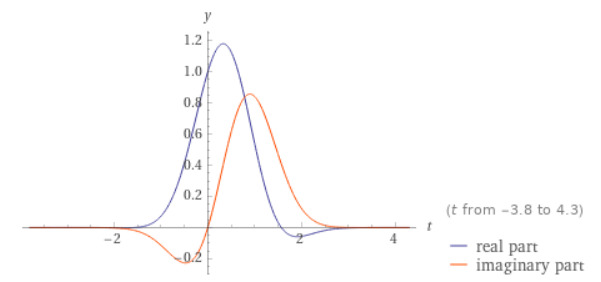

Com respectiva densidade de probabilidade

$$|\phi(t|0)|^2 = \frac{\sigma^2}{(2 \hbar \pi )^{3}} \dfrac{2{\pi}\mathrm{e}^{2\mathcal{Re}\left(-\frac{t^2}{2\sigma^2\hbar^2}+\frac{t_0t}{\sigma^2\hbar}-\frac{t_0^2}{2\sigma^2}\right)}\left|\mathrm{i}\sin\left(\frac{\epsilon_0 t}{\hbar^2}\right)+\cos\left(\frac{\epsilon_0 t}{\hbar^2}\right)\right|^2}{\sigma^2} = \frac{2{\pi}\mathrm{e}^{2\mathcal{Re}\left(-\frac{t^2}{2\sigma^2\hbar^2}+\frac{t_0t}{\sigma^2\hbar}-\frac{t_0^2}{2\sigma^2}\right)}\left|\mathrm{i}\sin\left(\frac{\epsilon_0 t}{\hbar^2}\right)+\cos\left(\frac{\epsilon_0 t}{\hbar^2}\right)\right|^2}{(2 \hbar \pi )^{3}} \tag{7.11}$$

Observe que até aqui, o [resultado](https://www.wolframalpha.com/input/?i=plot+%7Ce%5E%28-t%5E2%2B+t%29*%28cos%28t%29+%2B+i*sen+%28t%29%29%7C%5E2+PlottingRange%7B%7B-5%2C5%7D%2C%7B0%2C1.7%7D%7D) segue coerente visto que nossa expressão continua fazendo juz a gaussiana da condição inicial:

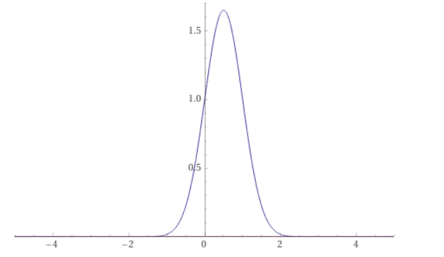

- Resultado espaço evoluído

$$ \phi (t|x) = \frac{1}{\sqrt{2 \pi \hbar}} \int d\epsilon \frac{\sigma^2}{ 2 \pi \hbar} \exp{\left ( - \frac{(\epsilon_0 + \hbar \epsilon)\left ( \sigma^2(\epsilon_0 + \hbar \epsilon)-2i \hbar t_0 \right ) }{2 \hbar^2} \right )} e^{(i/\hbar) \sqrt{2m\epsilon} x-i\epsilon t /\hbar } $$

$$=\frac{\sigma^4}{(2 \hbar \pi )^{3/2}} \int d\epsilon \exp{\left ( - \frac{(\epsilon_0 + \hbar \epsilon)\left ( \sigma^2(\epsilon_0 + \hbar \epsilon)-2i \hbar t_0 \right ) }{2 \hbar^2} \right )} e^{(i/\hbar) \sqrt{2m\epsilon} x-i\epsilon t /\hbar}$$

$$ =\text{integral não tem solução analítica} \blacksquare $$

$$\text{(note que ela não divergiu, apenas não tem solução analítica. Integrando numericamente para todas as constantes = 1 obtemos para a condição inicial: 1.390521824852123 + 0.2928372699906291 i)} $$

No intuito de eliminar a raíz do expoente que nos impossibilita essa integração, podemos então utilizar da construção de $\epsilon$ que como $P = \pm \sqrt{2 m \epsilon}$, isto é, $ \epsilon_p = P^2/2m $. Efetuando essa substituição vamos obter que:

$$\epsilon_p = \frac{P^2}{2m} \Rightarrow d\epsilon = \frac{P}{m} dP \tag{7.12}$$

Então, procedendo com a integração de 0 até $\infty$ (ao substituir o $P^2$ do expoente de $C_P$

$$ \phi (t|x) = \frac{1}{\sqrt{2 \pi \hbar}} \int dP \frac{P }{ m} \frac{\sigma^2}{ 2 \pi \hbar} \exp{\left ( - \frac{(P_0 + \frac{\hbar P^2}{2 m})\left ( \sigma^2(P_0 + \frac{\hbar P^2}{2 m})-2i \hbar t_0 \right ) }{2 \hbar^2} \right )} e^{(i/\hbar) P x - i P^2 t /2 m \hbar } $$

$$\phi (t|x) = \frac{\sigma^2}{ (2 \pi \hbar)^{3/2} m} \int dP P\exp{\left ( - \frac{(P_0 + \frac{\hbar P^2}{2 m})\left ( \sigma^2(P_0 + \frac{\hbar P^2}{2 m})-2i \hbar t_0 \right ) }{2 \hbar^2} \right )} e^{(i/\hbar) P x - i P^2 t /2 m\hbar } $$

*Observação: continuarei de forma analítica aqui, todavia fui capaz de resolver/plotar computacionalmente a integral acima; posso então trabalhar em gráficos complementares analiticos/computacionais a partir disso*

Setando o instante de tempo inicial $t_0$ como zero da nossa condição inicial gaussiana temporal, podemos simplificar nossa integral sem perder nenhum tipo de generalidade ou aplicação do problema, podendo então escrever a expressão como

$$ \phi (t|x) = \frac{\sigma^2}{ (2 \pi \hbar)^{3/2} m} \int dP P\exp{\left ( - \frac{ \sigma^2(P_0 + \frac{\hbar P^2}{2 m})^2 }{ 2 \hbar^2} \right )} e^{(i/\hbar) P x - i P^2 t /2 m\hbar }\tag{7.13}$$

Considerando a energia inicial como sendo $\epsilon_0 = 0$, isso nos leva de $\epsilon_0 = P_0^2/2m$ em $P_0 = 0$, que simplifica nossa integral mais uma vez em:

$$\phi (t|x) = \frac{\sigma^2}{ (2 \pi \hbar)^{3/2} m} \int dP P\exp{\left ( - \frac{\sigma^2 \hbar^4 P^4}{ m} \right )}e^{ - i P^2 t /2 m\hbar } e^{(i/\hbar) P x} \tag{7.14}$$

$$\textrm{erro: expoente com fator de 2 faltando}$$

Podemos reescrever o argumento das exponenciais que vão com $P^2$ da seguinte maneira:

$$ \left ( - \frac{\sigma^2 P^2}{ 2m\hbar} \right ) - \frac{i P^2 t }{2 m} = -\frac{b P^2}{2} $$

tomando $ b = \frac{1}{m \hbar} \left ( \sigma^2 + i t \right )$, podemos simplificar ambas as exponenciais para

$$\phi (t|x) = \frac{\sigma^2}{ (2 \pi \hbar)^{3/2} m} \int dP P e^{-\frac{b P^2}{2}} e^{(i/\hbar) P x} $$

cujo resultado da integral acima sabemos de [integrais tabeladas](https://www.wolframalpha.com/input/?i=integrate+exp%28-b*P%5E2%2F2%29*exp%28i*P*x%29*P+dP+from+0+to+%2B+inf) como sendo:

$$ I = \frac{1}{b} - \frac{\sqrt{\frac{\pi}{2}} x e^{-x^2/(2 b^2)} \left( \text{erfi} \left( \frac{x}{\sqrt{2 b}} \right) - i\right) }{b^{3/2}}$$

Fazendo então com que o resultado da função de onda espaço evoluída seja

$$\phi (t|x) = \frac{\sigma^2}{ (2 \pi \hbar)^{3/2} m} \left[ \frac{m \hbar}{\sigma^2 + it} - \frac{\sqrt{\frac{\pi}{2}} (m \hbar)^{3/2} x e^{-\frac{x^2 (m\hbar)^2}{(2 (\sigma^2+it)^2)}} \left( \text{erfi} \left( x \sqrt{\frac{\sigma^2 + it }{2 m \hbar}} \right) - i\right) }{(\sigma^2 + it)^{3/2}} \right] \tag{7.14-1}$$

(Tenho plots para mostrar tanto da função de onda quanto da densidade de probabilidade - posso mostrar 1 a 1, a animação ainda não tive tempo de implementar para vocês poderem visualizar a evolução)

Com respectiva densidade de probabilidade :

$$|\phi(t|x)|^2 = \frac{\sigma^4}{ (2 \pi \hbar)^{3}m^2 } \left[ \dfrac{\left(bx\mathrm{e}^\frac{x^2}{\mathrm{i}t+\sigma^2}\operatorname{erfi}\left(x\sqrt{\mathrm{i}t+\sigma^2}\right)-hm\sqrt{\mathrm{i}t+\sigma^2}-\mathrm{i}\right)^2}{\left|\mathrm{i}t+\sigma^2\right|^3} \right] \tag{7.15}$$

Para efeito de visualização, segue um plot do formato geral da função de onda evoluída em x = 1, utilizando 1 para todas as constantes e evoluindo ela numericamente em t:

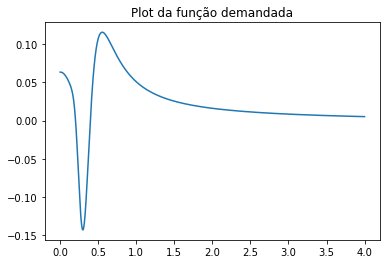

segue também o plot da densidade de probabilidade na posição x = 1,

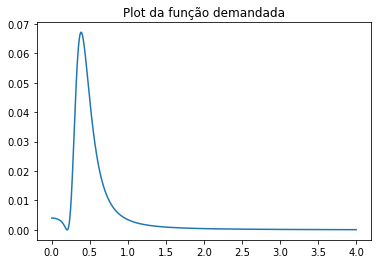

Note aqui que utilizamos embutido no resultado espacialmente evoluído a ideia de um propagador espacial para o sistema no intuito de obter $ \phi (t|x)$. A nível de curiosidade, vou desenvolver de forma geral a ideia de um propagador no escopo da teoria espelhada, e obter um resultado coerente com o que podemos observar em (7.10): para $x_0 = 0$, o propagador se torna $e^{(i/\hbar)\sqrt{2m \epsilon} x} $.

$$\textrm{Curiosidade: Desenvolvendo um propagador}$$

Perceba também que o termo da transformada $\exp (i\epsilon t)$, está associado para cada coeficiente $C_\epsilon$ com uma autofunção do nosso novo *Pamiltoniano* com autovalor em forma de $E_\epsilon = \sqrt{2 m \epsilon}/ \hbar$. Logo, nós sabemos que $\exp (i\epsilon t)$ deve evoluir no espaço com uma dependência espacial dada por $e^{-iE_\epsilon x /\hbar}$, devido ao formato do nosso *Pamiltoniano*, como mostraremos à seguir

Na intenção de examinar como um estado irá evoluir espacialmente, vamos restabelecer a definição de um propagador em nossa nova teoria como sendo um operador linear escrito como $\hat{U}(x,x_0)$, tal que

$$|\phi(x) \rangle = \hat{U}(x,x_0) |\phi(x_0) \rangle \tag{a.1}$$

podemos também inferir a seguinte propriedade:

$$\hat{U}(x_0,x_0) = \hat{I} \tag{a.2}$$

onde $\hat{I}$ é o operador unidade (identidade)

No propósito de avançar no que haviamos proposto anteriormente, precismos encontrar a forma analítica desse operador $\hat{U}(x,x_0)$, para isso, vamos simplesmente substituí-lo (7.9) na relação do *Pamiltoniano* de (4.14), isto é

$$ \mathcal{\hat{P}} \left ( \hat{U}(x,x_0)|\phi(x_0) \rangle \right ) = -i\hbar \frac{\partial }{\partial x} \left ( \hat{U}(x,x_0)|\phi(x_0) \rangle \right ) \tag {a.3}$$

ou,

$$\frac{\partial \hat{U}(x,x_0)}{\partial x} = \frac{i}{\hbar} \hat{P} \hat{U}(x,x_0) \tag{a.4}$$

Assumindo o *Pamiltoniano* espaço independente podemos proceder de forma parecida a MQ tradicional e integrar facilmente essa equação diferencial de forma a obter que

$$\boxed{\hat{U}(x,x_0) = e^{i(x-x_0)\hat{P}/\hbar} \longmapsto e^{i(x-x_0) \sqrt{2m\epsilon}/\hbar}} \tag{a.5}$$

A partir de agora, usaremos esse operador propagador de forma equivalente ao que fazemos para operar evoluções temporais na MQ tradicional, todavia, o faremos agora para evoluções espaciais no escopo da teoria espelhada.

$$\textrm{Fim}$$

Agora, seguindo em diante com o resultado encontrado, vamos verificar se o mesmo encontra-se tempo normalizado. Para isso, vamos analisar

$$ \int_{-\infty}^{\infty} |\phi(t|x)|^2 dt = 1 \tag{7.16}$$

Como ainda não resolvemos a questão da integração para a função de onda espaço evoluída, vamos analisar o caso condicionla de $x = 0$ que já podemos normalizar no tempo. Prosseguindo com:

$$ \int_{-\infty}^{\infty} |\phi(t|0)|^2 dt = 1 \tag{7.17}$$

$$1 = \int_{-\infty}^{\infty} \frac{2{\pi}\mathrm{e}^{2\mathcal{Re}\left(-\frac{t^2}{2\sigma^2\hbar^2}+\frac{t_0t}{\sigma^2\hbar}-\frac{t_0^2}{2\sigma^2}\right)}\left|\mathrm{i}\sin\left(\frac{\epsilon_0 t}{\hbar^2}\right)+\cos\left(\frac{\epsilon_0 t}{\hbar^2}\right)\right|^2}{(2 \hbar \pi )^{3}} dt \tag{7.18}$$

assumindo então $ \sigma, \hbar, \epsilon_0, t, t_0$ como reais podemos escrever nossa integral para a forma:

$$ \frac{\sigma^2}{(2 \hbar \pi )^{3}} \int_{-\infty}^{\infty} \dfrac{2{\pi}\mathrm{e}^{-\frac{t^2}{\sigma^2\hbar^2}+\frac{2t_0t}{\sigma^2 \hbar}-\frac{t_0^2}{\sigma^2}}}{\sigma^2} dt \tag{7.19}$$

Contraindo os termos do expoente no formato de quadrado da soma, pode convenientemente nos ajudar a enchergar uma função de erro de gauss, isto é:

$$ \frac{\sigma^2}{(2 \hbar \pi )^{3}} \int_{-\infty}^{\infty} \dfrac{2{\pi}\mathrm{e}^{-\frac{\left(t-t_0 \hbar \right)^2}{\sigma^2 \hbar^2}}}{\sigma^2} dt \Rightarrow \frac{\sigma^4}{(2 \hbar \pi )^{3}} \dfrac{{\pi}^\frac{3}{2}\hbar \operatorname{erf}\left(\frac{t}{\sigma \hbar}-\frac{t_0}{\sigma}\right)}{\sigma} \tag{7.20}$$

Substituindo os limites de integração, podemos então facilmente ver que

$$ \int_{-\infty}^{\infty} |\phi(t|0)|^2 dt = \frac{\sigma^2}{(2 \hbar \pi )^{3}} \dfrac{2{\pi}^\frac{3}{2}\hbar}{\sigma} = \frac{\sigma}{4 \hbar^2 \pi^{3/2}} \tag{7.21}$$

Logo, a constante de normalização pode ser simplesmente expressada através de $4 \hbar^2 \pi^{3/2}/\sigma$.

```python
import cmath
i = 0 + 1j
print('e^i =', cmath.exp(i))
print (i)
```

```
e^i = (0.5403023058681398+0.8414709848078965j)
1j
```

```python
def f(x):
    return x**2

print('f', x)
```

```python
(-1) ** 0.5
```

```
(6.123233995736766e-17+1j)
```

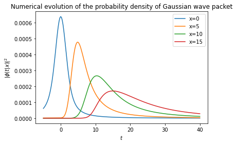

```python
import quadpy
import math as math
from math import e
from math import pi
from math import sqrt
import numpy as np
from scipy import integrate
import matplotlib.pyplot as plt
import cmath
from scipy.optimize import fmin

#definindo unidade imaginária:
i = 0 + 1j

#criando a função para o plot
def plot_results(sigma = 1, Xp = 1, m=1, P_0 = 1, hbar = 1):

    #preparando a função que vai ser integrada para a integração
    def f(x, t):
        res = (sigma**2)/(2*pi*hbar)**(3/2)*x*e**(-(P_0 + hbar*(x**2)/(2*m))*(sigma**2)*(P_0 + hbar*(x**2)/(2*m))/(2*hbar**2))*cmath.exp((i/hbar)*x*Xp - i*(x**2)*t/(2*m*hbar))
        return res
    integral = np.vectorize(f)

    #efetuando a integral
    def F(t):
        xmin = 0
        xmax = 10
        y,err = quadpy.quad(lambda x: integral(x,t), xmin, xmax)
        return y
    Fvec = np.vectorize(F)
    """
    def piu(x):
        return  fmin(Fvec, 0, args=(x))
    #print('piu', x)
    """
    return Fvec

X0 = plot_results(1,0,1,1,1)
X1 = plot_results(1,5,1,1,1)
X2 = plot_results(1,10,1,1,1)
X3 = plot_results(1,15,1,1,1)

t = np.linspace(-5,40,200)
plt.plot(t, abs(X0(t))**2, label='x=0')
plt.plot(t, abs(X1(t))**2, label='x=5')
plt.plot(t, abs(X2(t))**2, label='x=10')
plt.plot(t, abs(X3(t))**2, label='x=15')
plt.legend()
plt.title('Numerical evolution of the probability density of Gaussian wave packet')
plt.ylabel('$|\phi(t|x)|^2$')
plt.xlabel('$t$')
```

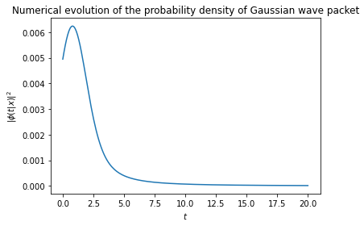

```python
from scipy.integrate import quad
from math import exp, cos, sin, pi, sqrt
import numpy as np
import matplotlib.pyplot as plt

#defina aqui as constantes:
sigma = 1
hbar = 1
m = 1
P_0 = 0
i = 0 + 1j
x = 8

#preparando a função que vai ser integrada para a integração, dividida em real e imaginária
#parte real:
def re(p, t):
   RE = (sigma**2)/(2*pi*hbar)**(3/2)*p*exp(-(P_0 + hbar*(p**2)/(2*m))*(sigma**2)*(P_0 + hbar*(p**2)/(2*m))/(2*hbar**2))*cos((1/hbar)*p*x - 1*(p**2)*t/(2*m*hbar))
   return RE
integral1 = np.vectorize(re)

#parte imaginária
def im(p, t):
    IM = (sigma**2)/(2*pi*hbar)**(3/2)*p*exp(-(P_0 + hbar*(p**2)/(2*m))*(sigma**2)*(P_0 + hbar*(p**2)/(2*m))/(2*hbar**2))*sin((1/hbar)*p*x - 1*(p**2)*t/(2*m*hbar))
    return IM
integral2 = np.vectorize(im)


#efetuando a integral em p e passando t para ser o argumento da função de onda
def F(t):
    min = 0
    max = 10
    y, err = quad(integral1, min, max, args=(t))
    return y


def M(t):
    min = 0
    max = 10
    y, err = quad(integral2, min, max, args=(t))
    return y

def OP(t):
    return abs(F(t) + M(t)*i)**2
OPvec = np.vectorize(OP)

t = np.linspace(-0,20,200)
plt.plot(t, OPvec(t))
plt.title('Numerical evolution of the probability density of Gaussian wave packet')
plt.ylabel('$|\phi(t|x)|^2$')
plt.xlabel('$t$')
```

```
4
0.21089492298047324
```

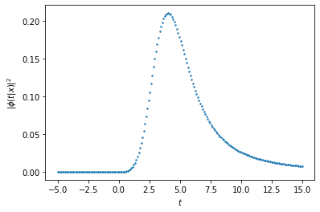

```python
from scipy.integrate import quad
from math import exp, cos, sin, pi
import numpy as np
import matplotlib.pyplot as plt

#defina aqui as constantes:
sigma = 1
hbar = 1
m = 1
P_0 = 0
i = 0 + 1j
n = 15
irio = 100
piu = np.zeros(irio)
valor_x = np.zeros(n)
maximum = np.zeros(n)
tuntime = np.zeros(n)

x = 5



#preparando a função que vai ser integrada para a integração, dividida em real e imaginária
#parte real:
def re(p, t):
    RE = (sigma**2)/(2*pi*hbar)**(3/2)*p*exp(-(P_0 + hbar*(p**2)/(2*m))*(sigma**2)*(P_0 + hbar*(p**2)/(2*m))/(2*hbar**2))*cos((1/hbar)*p*x - 1*(p**2)*t/(2*m*hbar))
    return RE
integral1 = np.vectorize(re)

#parte imaginária
def im(p, t):
    IM = (sigma**2)/(2*pi*hbar)**(3/2)*p*exp(-(P_0 + hbar*(p**2)/(2*m))*(sigma**2)*(P_0 + hbar*(p**2)/(2*m))/(2*hbar**2))*sin((1/hbar)*p*x - 1*(p**2)*t/(2*m*hbar))
    return IM
integral2 = np.vectorize(im)


#efetuando a integral em p e passando t para ser o argumento da função de onda
def F(t):
    min = 0
    max = 20
    y, err = quad(integral1, min, max, args=(t))
    return y


def M(t):
    min = 0
    max = 20
    y, err = quad(integral2, min, max, args=(t))
    return y

def OP(t):
    return abs(F(t) + M(t)*i)**2
OPvec = np.vectorize(OP)

#integrando em t para obter a função de normalização
def norm(t):
    min = -20
    max = 20
    y, err = quad(OPvec, min, max)
    return y


#normalizando
def graph(t):
    return OP(t)/norm(t)
graph_vec = np.vectorize(graph)

for k in range (irio):
    piu[k] = graph(k)

tuntime = np.argmax(piu)
print(tuntime)
maximum = np.amax(piu)
print(maximum)


#organizando o plot da função em questão
t = np.linspace(-5,15,200)
plt.scatter(t, graph_vec(t), s = 2)
plt.ylabel('$|\phi(t|x)|^2$')
plt.xlabel('$t$')
```